# Content

## 6.24. Capital loss

- Quite many people have a capital loss equal to `zero`.

```python
data[['capital.loss']].describe()
```

|  | capital.loss |
| --- | --- |
| count | 32537.000000 |
| mean | 87.368227 |
| std | 403.101833 |
| min | 0.000000 |
| 25% | 0.000000 |
| 50% | 0.000000 |
| 75% | 0.000000 |
| max | 4356.000000 |

```python
data.loc[data['capital.loss'] == 0, 'capital.loss'].count()
```

```
31018
```

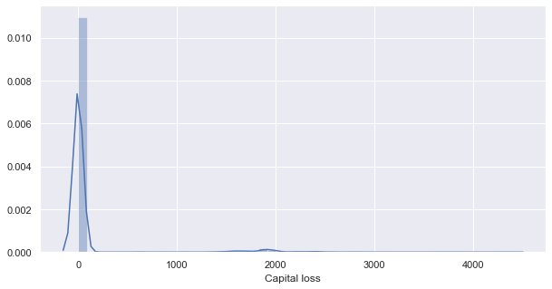

```python
plt.figure(figsize=(10, 5))
sns.distplot(data['capital.loss'])

plt.xlabel("Capital loss");
```

## 6.25. Capital loss & Income

- Quite many people who earn `<=50K` or `>50K` have a capital loss equal to `zero`.

```python
data.groupby(by='income')['capital.loss'].describe().T
```

| income | <=50K | >50K |
| --- | --- | --- |
| count | 24698.000000 | 7839.000000 |
| mean | 53.190258 | 195.051282 |
| std | 310.890099 | 595.555395 |
| min | 0.000000 | 0.000000 |
| 25% | 0.000000 | 0.000000 |
| 50% | 0.000000 | 0.000000 |
| 75% | 0.000000 | 0.000000 |
| max | 4356.000000 | 3683.000000 |

```python
data.loc[(data['capital.loss'] == 0) & (data['income'] == '<=50K'), 'capital.loss'].count()
```

```
23952
```

```python
data.loc[(data['capital.loss'] == 0) & (data['income'] == '>50K'), 'capital.loss'].count()
```

```
7066
```

- Capital loss of people who earn `>50K` is larger than those who earn `<=50K`.

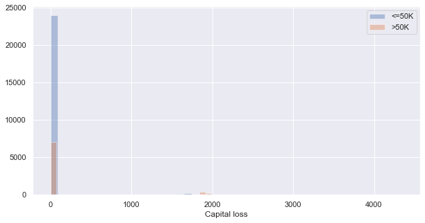

```python
plt.figure(figsize=(10, 5))
sns.distplot(data.loc[data['income'] == '<=50K', 'capital.loss'], kde=False, label='<=50K')
sns.distplot(data.loc[data['income'] == '>50K', 'capital.loss'], kde=False, label='>50K')

plt.xlabel("Capital loss");
plt.legend();
```

## 6.26. Hours per week

- Quite many people work `40` hours per week.
- Can be observed that many people work `50` hours per week.

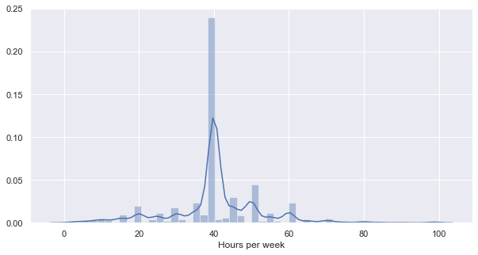

```python
plt.figure(figsize=(10, 5))
sns.distplot(data['hours.per.week'])

plt.xlabel("Hours per week");
```

- Average number of working hours per week is `40`.

```python
data[['hours.per.week']].describe()
```

|  | hours.per.week |
| --- | --- |
| count | 32537.000000 |
| mean | 40.440329 |
| std | 12.346889 |
| min | 1.000000 |
| 25% | 40.000000 |
| 50% | 40.000000 |
| 75% | 45.000000 |
| max | 99.000000 |

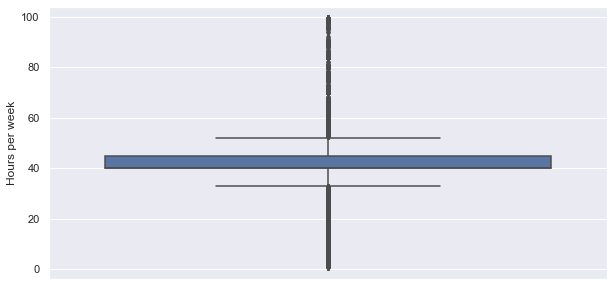

```python
plt.figure(figsize=(10, 5))
sns.boxplot(y='hours.per.week', data=data)

plt.ylabel("Hours per week");
```